# EDA

# 0. Carregando pacotes e dados necessários

```r
library(dplyr)
library(gridExtra)
library(car)
library(psych)
library(nnet)
library(AER)
library(lmtest)
library(gtsummary)
library(reshape2)
```

```r
library(ggplot2)
library(DescTools)
library(mlogit)
library(tidyverse)
```

### #Carregando o banco de dados

Iremos começar importando os dados dos arquivos .CSV; também iremos mudar os nomes das colunas de nossa base para facilitar a utilização e evitar linhas muito longas.

```r
Dados=read.csv("desafio_manutencao_preditiva_treino.csv")
Dados_teste=read.csv("desafio_manutencao_preditiva_teste.csv")
Base=Dados
Base_teste=Dados_teste

colnames(Base)=c("udi","pid","type","airtemp","protemp","rotspeed","torque","toolwear","errort")

colnames(Base_teste)=c("udi","pid","type","airtemp","protemp","rotspeed","torque","toolwear")
```

### #Convertendo variáveis

Para início de nossa análise exploratória, iremos montar um sumário geral com todas as variáveis, além de buscar valores faltantes.

```r
summary(Base)
```

```
##       udi            pid                type              airtemp
##  Min.   :    1   Length:6667        Length:6667        Min.   :295.3
##  1st Qu.: 2496   Class :character   Class :character   1st Qu.:298.3
##  Median : 4983   Mode  :character   Mode  :character   Median :300.0
##  Mean   : 4995                                         Mean   :300.0
##  3rd Qu.: 7510                                         3rd Qu.:301.5
##  Max.   :10000                                         Max.   :304.5
##     protemp         rotspeed        torque         toolwear
##  Min.   :305.7   Min.   :1168   Min.   : 3.80   Min.   :  0.0
##  1st Qu.:308.8   1st Qu.:1422   1st Qu.:33.20   1st Qu.: 54.0
##  Median :310.0   Median :1503   Median :40.20   Median :108.0
##  Mean   :310.0   Mean   :1537   Mean   :40.06   Mean   :108.1
##  3rd Qu.:311.1   3rd Qu.:1612   3rd Qu.:46.80   3rd Qu.:162.0
##  Max.   :313.8   Max.   :2886   Max.   :76.60   Max.   :251.0
##     errort
##  Length:6667
##  Class :character
##  Mode  :character
##
##
##
```

```r
###Como vimos no sumário, temos as variáveis "Type" e "Errort" como caracteres. Iremos converte-las para fatores para que possamos trabalhar com elas futuramente.

Base=as.data.frame(unclass(Base),stringsAsFactors = TRUE)
summary(Base)
```

```
##       udi             pid       type        airtemp         protemp
##  Min.   :    1   H29424 :   1   H: 658   Min.   :295.3   Min.   :305.7
##  1st Qu.: 2496   H29425 :   1   L:4022   1st Qu.:298.3   1st Qu.:308.8
##  Median : 4983   H29432 :   1   M:1987   Median :300.0   Median :310.0
##  Mean   : 4995   H29441 :   1            Mean   :300.0   Mean   :310.0
##  3rd Qu.: 7510   H29452 :   1            3rd Qu.:301.5   3rd Qu.:311.1
##  Max.   :10000   H29457 :   1            Max.   :304.5   Max.   :313.8
##                  (Other):6661
##     rotspeed        torque         toolwear                          errort
##  Min.   :1168   Min.   : 3.80   Min.   :  0.0   Heat Dissipation Failure:  75
##  1st Qu.:1422   1st Qu.:33.20   1st Qu.: 54.0   No Failure              :6435
##  Median :1503   Median :40.20   Median :108.0   Overstrain Failure      :  52
##  Mean   :1537   Mean   :40.06   Mean   :108.1   Power Failure           :  63
##  3rd Qu.:1612   3rd Qu.:46.80   3rd Qu.:162.0   Random Failures         :  12
##  Max.   :2886   Max.   :76.60   Max.   :251.0   Tool Wear Failure       :  30
##
```

```r
###Em seguida, iremos contar os NAs para verificar se há valores faltantes.
sapply(Base, function(x) sum(is.na(x)))
```

```
##      udi      pid     type  airtemp  protemp rotspeed   torque toolwear
##        0        0        0        0        0        0        0        0
##   errort
##        0
```

Replicaremos o processo para a base que será utilizada no teste.

```r
summary(Base_teste)
```

```
##       udi           pid                type              airtemp
##  Min.   :   3   Length:3333        Length:3333        Min.   :295.3
##  1st Qu.:2515   Class :character   Class :character   1st Qu.:298.4
##  Median :5023   Mode  :character   Mode  :character   Median :300.1
##  Mean   :5012                                         Mean   :300.0
##  3rd Qu.:7470                                         3rd Qu.:301.6
##  Max.   :9998                                         Max.   :304.4
##     protemp         rotspeed        torque         toolwear
##  Min.   :305.7   Min.   :1202   Min.   : 4.60   Min.   :  0.0
##  1st Qu.:308.9   1st Qu.:1425   1st Qu.:33.10   1st Qu.: 51.0
##  Median :310.1   Median :1503   Median :39.90   Median :108.0
##  Mean   :310.0   Mean   :1541   Mean   :39.84   Mean   :107.7
##  3rd Qu.:311.1   3rd Qu.:1612   3rd Qu.:46.60   3rd Qu.:163.0
##  Max.   :313.8   Max.   :2861   Max.   :70.00   Max.   :253.0
```

```r
###Como vimos no sumário, temos as variáveis "Type" e "Errort" como caracteres. Iremos converte-las para fatores para que possamos trabalhar com elas futuramente.

Base_teste=as.data.frame(unclass(Base_teste),stringsAsFactors = TRUE)
summary(Base_teste)
```

```
##       udi            pid       type        airtemp         protemp
##  Min.   :   3   H29434 :   1   H: 345   Min.   :295.3   Min.   :305.7
##  1st Qu.:2515   H29552 :   1   L:1978   1st Qu.:298.4   1st Qu.:308.9
##  Median :5023   H29560 :   1   M:1010   Median :300.1   Median :310.1
##  Mean   :5012   H29571 :   1            Mean   :300.0   Mean   :310.0
##  3rd Qu.:7470   H29610 :   1            3rd Qu.:301.6   3rd Qu.:311.1
##  Max.   :9998   H29626 :   1            Max.   :304.4   Max.   :313.8
##                 (Other):3327
##     rotspeed        torque         toolwear
##  Min.   :1202   Min.   : 4.60   Min.   :  0.0
##  1st Qu.:1425   1st Qu.:33.10   1st Qu.: 51.0
##  Median :1503   Median :39.90   Median :108.0
##  Mean   :1541   Mean   :39.84   Mean   :107.7
##  3rd Qu.:1612   3rd Qu.:46.60   3rd Qu.:163.0
##  Max.   :2861   Max.   :70.00   Max.   :253.0
##
```

```r
###Em seguida, iremos contar os NAs para verificar se há valores faltantes.
sapply(Base_teste, function(x) sum(is.na(x)))
```

```
##      udi      pid     type  airtemp  protemp rotspeed   torque toolwear
##        0        0        0        0        0        0        0        0
```

# **#####1. EDA#####**

Com a confirmação que não temos valores faltantes, iremos começar a análisar as variáveis individualmente.

- Em nossa análise, iremos observar a centralidade das amostras através da média e da mediana. Para a variável categórica Type, utilizaremos um histograma para ver qual é a maior repetição desta.
- Além disso, observaremos valores como amplitude e desvio padrão para observarmos a variabilidade das variáveis.
- Também contaremos com análise gráfica de boxplot em busca de outliers, principalmente aqueles de magnitude extrema. Utilizaremos o histograma e uma curva de densidade para observarmos o quanto se assemelha a distribuição da variável com uma distribuição normal.

### **#Type#**

Iniciaremos a análise exploratória com a variável categórica “Type”. Buscaremos nela dados fora do domínio estabelecido, ou seja, diferentes de H, M ou L.

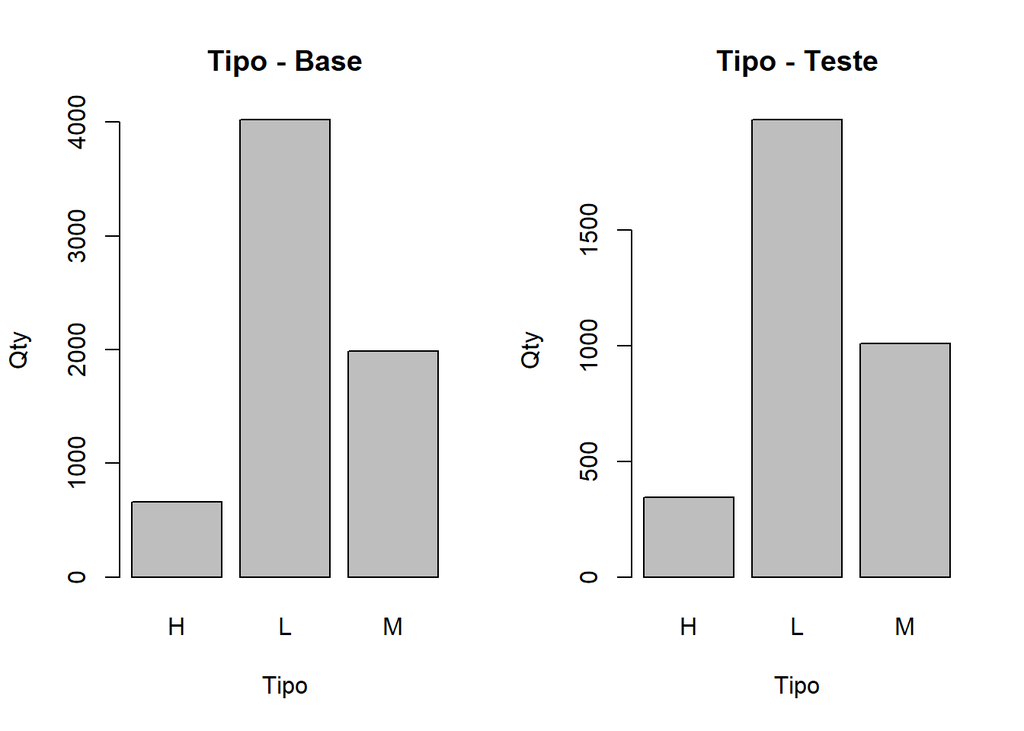

```r
tipo = table(Base$type)
tipo_teste = table(Base_teste$type)

par(mfrow=c(1,2))
barplot(tipo,main="Tipo - Base",xlab="Tipo",ylab="Qty")
barplot(tipo_teste,main="Tipo - Teste",xlab="Tipo",ylab="Qty")
```

Com o gráfico podemos observar que não há observações fora do domínio esperado e também uma maior presença do tipo “`Low`”

### **#Airtemp#**

Partindo para as variáveis quantitativas, iremos começar com a variável “airtemp”

```r
summary(Base$airtemp)
```

```
##    Min. 1st Qu.  Median    Mean 3rd Qu.    Max.
##   295.3   298.3   300.0   300.0   301.5   304.5
```

```r
sd(Base$airtemp)
```

```
## [1] 1.99471
```

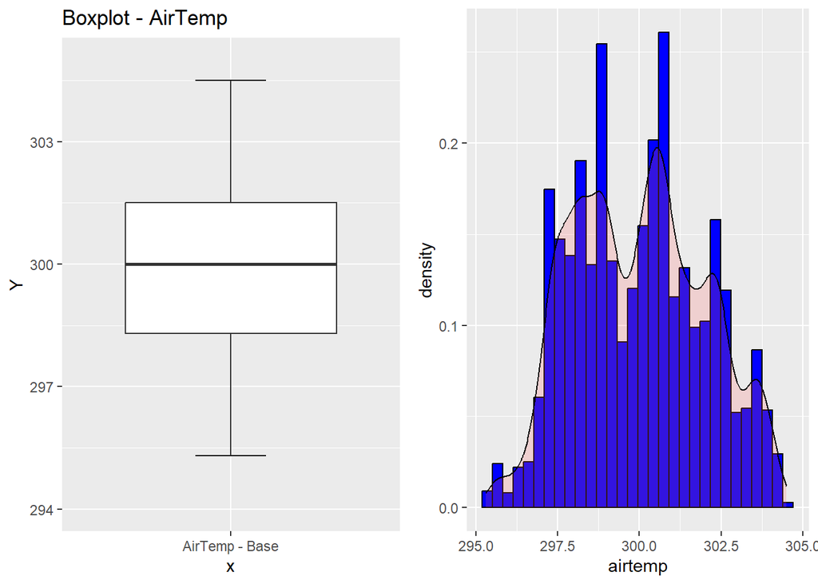

```r
a=ggplot(Base, aes(y=airtemp, x="AirTemp - Base")) +
  stat_boxplot(geom ="errorbar", width=0.25) +
  geom_boxplot() +
  labs(title = "Boxplot - AirTemp")+
  ylab("Y")+
  ylim(294,305)

b=ggplot(Base, aes(x=airtemp)) +
  geom_histogram(aes(y=..density..),color="Black",fill="Blue")+
  geom_density(alpha=.2,fill="#FF6666")

grid.arrange(a,b,ncol=2)
```

```r
summary(Base_teste$airtemp)
```

```
##    Min. 1st Qu.  Median    Mean 3rd Qu.    Max.
##   295.3   298.4   300.1   300.0   301.6   304.4
```

```r
sd(Base_teste$airtemp)
```

```
## [1] 2.011382
```

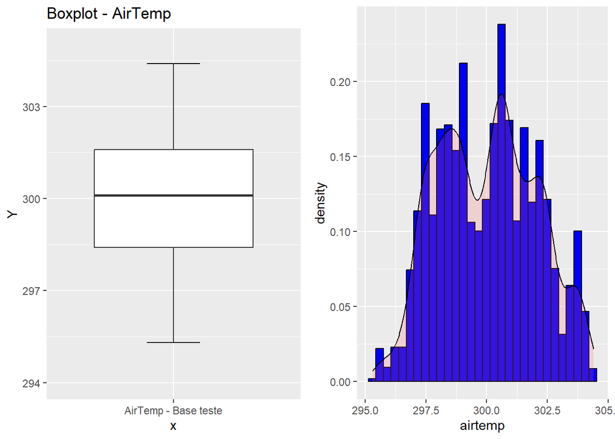

```r
c=ggplot(Base_teste, aes(y=airtemp, x="AirTemp - Base teste")) +
  stat_boxplot(geom ="errorbar", width=0.25) +
  geom_boxplot() +
  labs(title = "Boxplot - AirTemp")+
  ylab("Y")+
  ylim(294,305)

d=ggplot(Base_teste, aes(x=airtemp)) +
  geom_histogram(aes(y=..density..),color="Black",fill="Blue")+
  geom_density(alpha=.2,fill="#FF6666")

grid.arrange(c,d,ncol=2)
```

Para a variável airtemp, vemos que a média e a mediana possuem os mesmos valores, indicando dados com distribuição não viésada, o que podemos observar também no histograma, que ausenta caudas. Além disso, o boxplot e a amplitude dos dados confirmam a ausência de outliers. Por fim, temos um desvio padrão pequeno, indicando a proximidade dos dados a média.

### **#Protemp#**

```r
summary(Base$protemp)
```

```
##    Min. 1st Qu.  Median    Mean 3rd Qu.    Max.
##   305.7   308.8   310.0   310.0   311.1   313.8
```

```r
sd(Base$protemp)
```

```
## [1] 1.488101
```

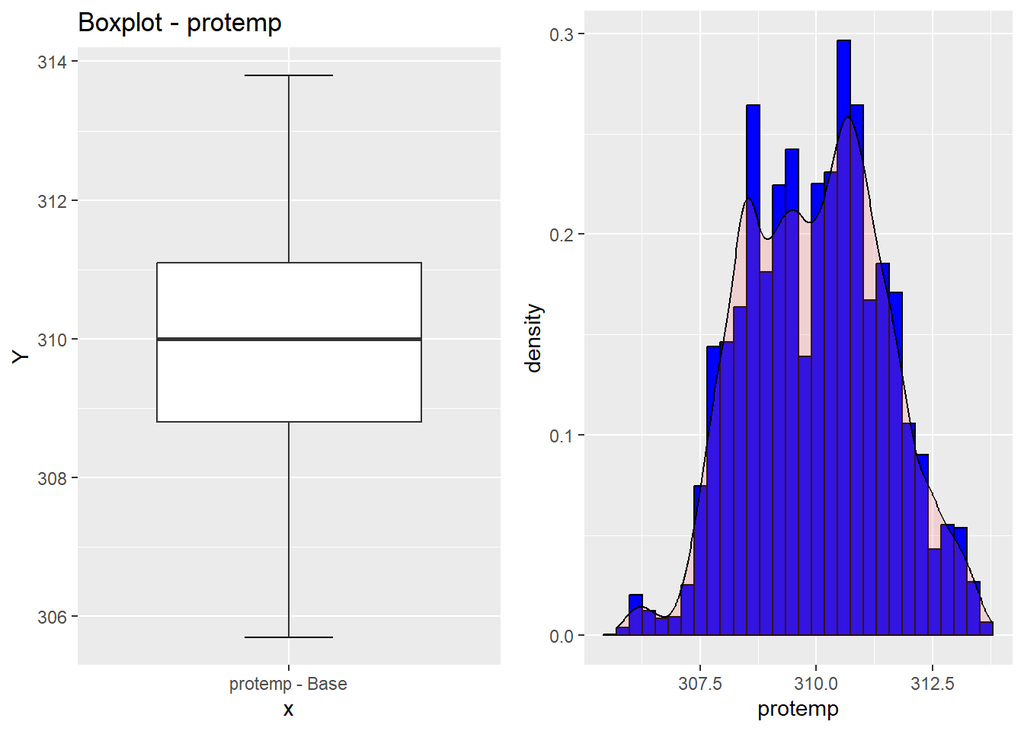

```r
a=ggplot(Base, aes(y=protemp, x="protemp - Base")) +
  stat_boxplot(geom ="errorbar", width=0.25) +
  geom_boxplot() +
  labs(title = "Boxplot - protemp")+
  ylab("Y")

b=ggplot(Base, aes(x=protemp)) +
  geom_histogram(aes(y=..density..),color="Black",fill="Blue")+
  geom_density(alpha=.2,fill="#FF6666")

grid.arrange(a,b,ncol=2)
```

```r
summary(Base_teste$protemp)
```

```
##    Min. 1st Qu.  Median    Mean 3rd Qu.    Max.
##   305.7   308.9   310.1   310.0   311.1   313.8
```

```r
sd(Base_teste$protemp)
```

```
## [1] 1.474842
```

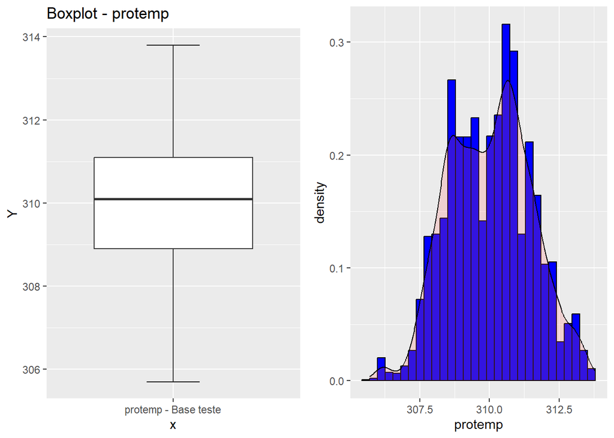

```r
c=ggplot(Base_teste, aes(y=protemp, x="protemp - Base teste")) +
  stat_boxplot(geom ="errorbar", width=0.25) +
  geom_boxplot() +
  labs(title = "Boxplot - protemp")+
  ylab("Y")

d=ggplot(Base_teste, aes(x=protemp)) +
  geom_histogram(aes(y=..density..),color="Black",fill="Blue")+
  geom_density(alpha=.2,fill="#FF6666")

grid.arrange(c,d,ncol=2)
```

De modo semelhante ao observado na variável anterior, a variável “protemp” também possui média e mediana iguais, indicando dados não viésados em conjunto com a ausência de caudas. Seu desvio padrão é pequeno e não temos a presença de outliers na amostra.

### **#Rotspeed#**

```r
summary(Base$rotspeed)
```

```
##    Min. 1st Qu.  Median    Mean 3rd Qu.    Max.
##    1168    1422    1503    1537    1612    2886
```

```r
sd(Base$rotspeed)
```

```
## [1] 177.1829
```

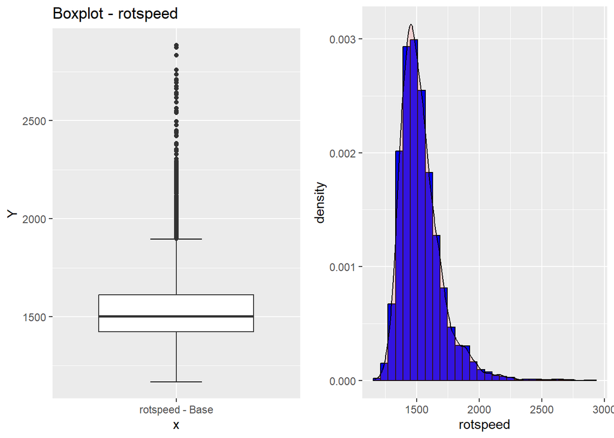

```r
a=ggplot(Base, aes(y=rotspeed, x="rotspeed - Base")) +
  stat_boxplot(geom ="errorbar", width=0.25) +
  geom_boxplot() +
  labs(title = "Boxplot - rotspeed")+
  ylab("Y")

b=ggplot(Base, aes(x=rotspeed)) +
  geom_histogram(aes(y=..density..),color="Black",fill="Blue")+
  geom_density(alpha=.2,fill="#FF6666")

grid.arrange(a,b,ncol=2)
```

```r
summary(Base_teste$rotspeed)
```

```
##    Min. 1st Qu.  Median    Mean 3rd Qu.    Max.
##    1202    1425    1503    1541    1612    2861
```

```r
sd(Base_teste$rotspeed)
```

```
## [1] 183.4117
```

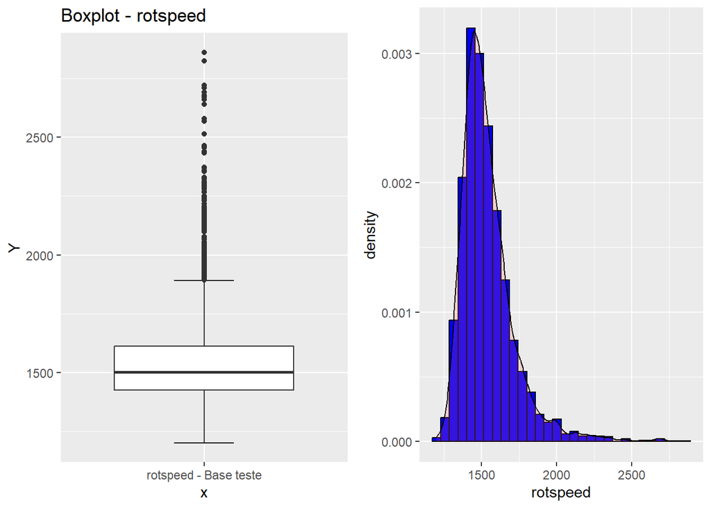

```r
c=ggplot(Base_teste, aes(y=rotspeed, x="rotspeed - Base teste")) +
  stat_boxplot(geom ="errorbar", width=0.25) +
  geom_boxplot() +
  labs(title = "Boxplot - rotspeed")+
  ylab("Y")

d=ggplot(Base_teste, aes(x=rotspeed)) +
  geom_histogram(aes(y=..density..),color="Black",fill="Blue")+
  geom_density(alpha=.2,fill="#FF6666")

grid.arrange(c,d,ncol=2)
```

### **#Torque#**

```r
summary(Base$torque)
```

```
##    Min. 1st Qu.  Median    Mean 3rd Qu.    Max.
##    3.80   33.20   40.20   40.06   46.80   76.60
```

```r
sd(Base$torque)
```

```
## [1] 9.950804
```

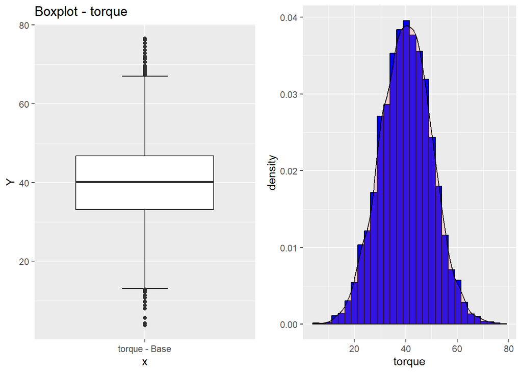

```r
a=ggplot(Base, aes(y=torque, x="torque - Base")) +
  stat_boxplot(geom ="errorbar", width=0.25) +
  geom_boxplot() +
  labs(title = "Boxplot - torque")+
  ylab("Y")

b=ggplot(Base, aes(x=torque)) +
  geom_histogram(aes(y=..density..),color="Black",fill="Blue")+
  geom_density(alpha=.2,fill="#FF6666")

grid.arrange(a,b,ncol=2)
```

```r
summary(Base_teste$torque)
```

```
##    Min. 1st Qu.  Median    Mean 3rd Qu.    Max.
##    4.60   33.10   39.90   39.84   46.60   70.00
```

```r
sd(Base_teste$torque)
```

```
## [1] 10.00506
```

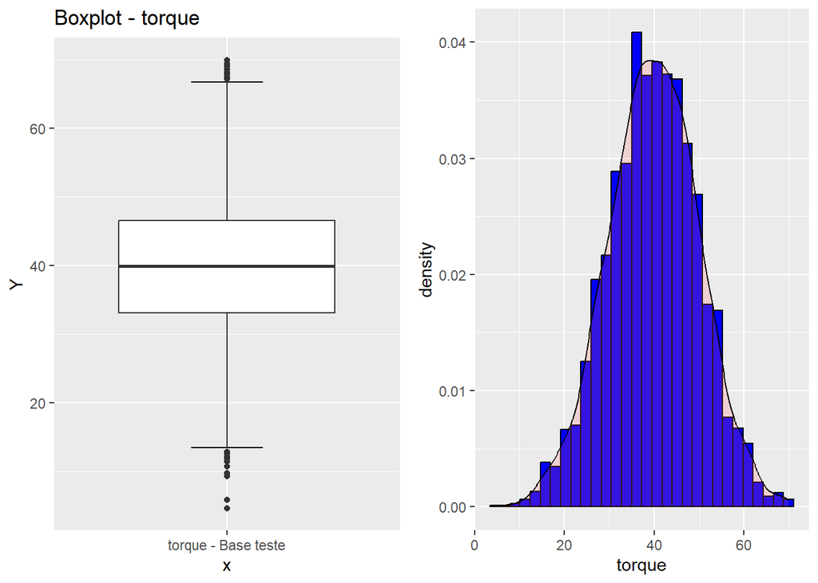

```r
c=ggplot(Base_teste, aes(y=torque, x="torque - Base teste")) +
  stat_boxplot(geom ="errorbar", width=0.25) +
  geom_boxplot() +
  labs(title = "Boxplot - torque")+
  ylab("Y")

d=ggplot(Base_teste, aes(x=torque)) +
  geom_histogram(aes(y=..density..),color="Black",fill="Blue")+
  geom_density(alpha=.2,fill="#FF6666")

grid.arrange(c,d,ncol=2)
```

A variável **Torque** apresentou uma distribuição bem semelhante a normal, com média e mediana semelhantes e um desvio padrão pequeno. Todavia, podemos observar através do boxplot a presença de outlier em ambos os lados da amostra, mas estes não chegam a valores extremos.

### **#Toolwear#**

```r
summary(Base$toolwear)
```

```
##    Min. 1st Qu.  Median    Mean 3rd Qu.    Max.
##     0.0    54.0   108.0   108.1   162.0   251.0
```

```r
sd(Base$toolwear)
```

```
## [1] 63.35991
```

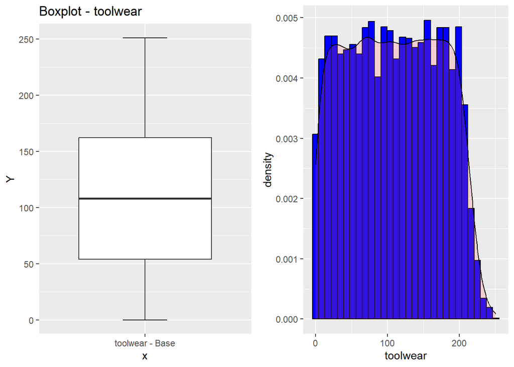

```r
a=ggplot(Base, aes(y=toolwear, x="toolwear - Base")) +
  stat_boxplot(geom ="errorbar", width=0.25) +
  geom_boxplot() +
  labs(title = "Boxplot - toolwear")+
  ylab("Y")

b=ggplot(Base, aes(x=toolwear)) +
  geom_histogram(aes(y=..density..),color="Black",fill="Blue")+
  geom_density(alpha=.2,fill="#FF6666")

grid.arrange(a,b,ncol=2)
```

```r
summary(Base_teste$toolwear)
```

```
##    Min. 1st Qu.  Median    Mean 3rd Qu.    Max.
##     0.0    51.0   108.0   107.7   163.0   253.0
```

```r
sd(Base_teste$toolwear)
```

```
## [1] 64.2472
```

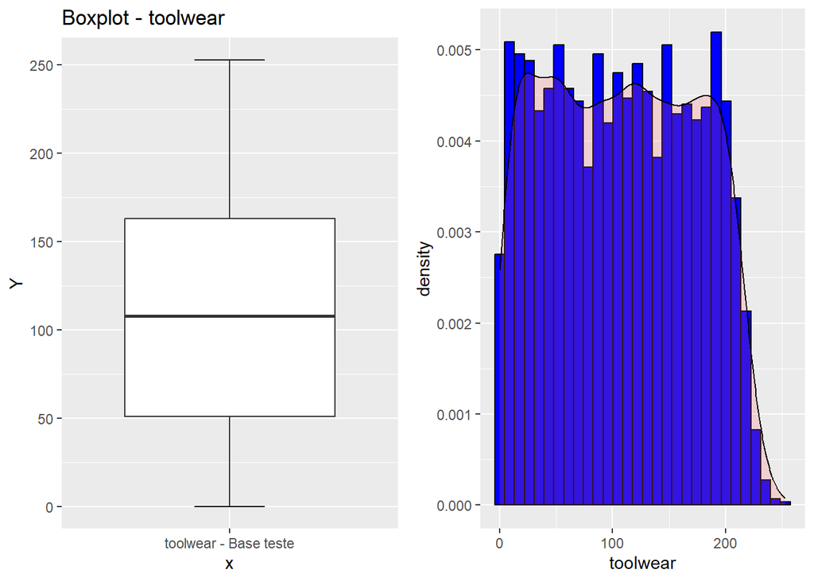

```r
c=ggplot(Base_teste, aes(y=toolwear, x="toolwear - Base teste")) +
  stat_boxplot(geom ="errorbar", width=0.25) +
  geom_boxplot() +
  labs(title = "Boxplot - toolwear")+
  ylab("Y")

d=ggplot(Base_teste, aes(x=toolwear)) +
  geom_histogram(aes(y=..density..),color="Black",fill="Blue")+
  geom_density(alpha=.2,fill="#FF6666")

grid.arrange(c,d,ncol=2)
```

A variável **toolwear** apresentou uma distribuição semelhante para todos os niveis até a base acima de 200, onde decaiu rapidamente. Isso demonstra uma menor concentração no lado direito da amostra e que não está normalmente distribuida. Mesmo sem detectar outliers através do boxplot, temos um grande desvio padrão.

# #####2. Previsão do tipo de falha

Para a previsão do tipo de falha, iremos utilizar um modelo de **Regressão Logistica multinomial**, pois estamos tratando de uma variável **categórica**, o tipo de erro da máquina.

```r
#inicialmente, iremos alterar a referencia da variável explorada para a "No Failure", permitindo assim que ela seja a base a ser comparada com as demais categorias.

Base$errort = relevel(Base$errort, ref= "No Failure")
levels(Base$errort)
```

```
## [1] "No Failure"               "Heat Dissipation Failure"
## [3] "Overstrain Failure"       "Power Failure"
## [5] "Random Failures"          "Tool Wear Failure"
```

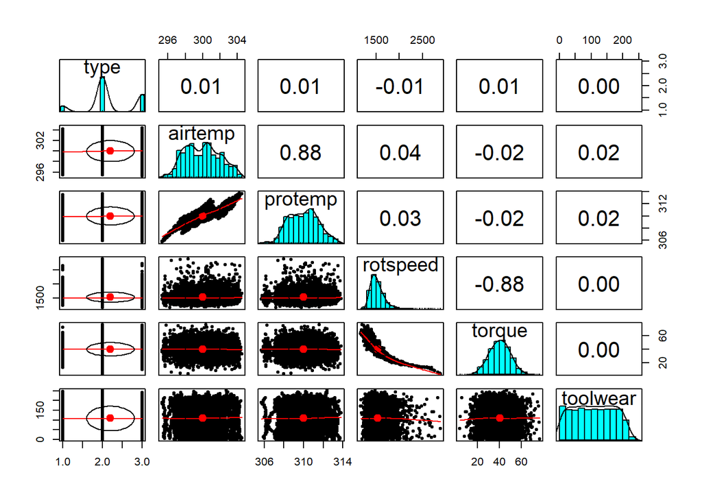

```r
#Agora iremos analisar graficamente a existencia de multicolinearidade entre as variáveis explicativas.

pairs.panels(Base[3:8])
```

```r
#Como tivemos um valor alto entre as variáveis airtemp/protemp, e rotspeed/torque iremos realizar também um teste "vif" para analisar mais a fundo a multicolinearidade.

testemc=lm(as.numeric(errort)~airtemp+protemp+rotspeed+type+torque+toolwear, data=Base)
vif(testemc)
```

```
##              GVIF Df GVIF^(1/(2*Df))
## airtemp  4.292898  1        2.071931
## protemp  4.290493  1        2.071351
## rotspeed 4.303780  1        2.074555
## type     1.000749  2        1.000187
## torque   4.300759  1        2.073827
## toolwear 1.000742  1        1.000371
```

```r
#No teste VIF obtivemos valores abaixo de 5 para todas as variáveis, então, apesar de próximos, iremos considerar a não existencia de multicolinearidade no modelo.
```

Agora testaremos em busca de categorias irrelevantes de acordo com o teste de Hausman-McFadden, excluindo a categoria “Random Failures” para verificar se os erros aleatórios tem impacto em nosso modelo.

```r
regcomp=mlogit(errort~1|type+airtemp+protemp+rotspeed+torque+toolwear,
               data=Base, shape="wide",
               reflevel="No Failure")

regsemerro=mlogit(errort~1|type+airtemp+protemp+rotspeed+torque+toolwear,
               data=Base, shape="wide",
               reflevel="No Failure",
               alt.subset=c("No Failure", "Heat Dissipation Failure", "Overstrain Failure", "Power Failure","Tool Wear Failure"))

hmftest(regcomp,regsemerro)
```

```
##
##  Hausman-McFadden test
##
## data:  Base
## chisq = 1.4311, df = 32, p-value = 1
## alternative hypothesis: IIA is rejected
```

Com a rejeição da hipotese alternativa, não rejeitamos a hipotese nula e portanto não levaremos a categoria “Random Failures” como irrelevante.

Agora, iremos estimar uma regressão multinomial para nossa variável dependente utilizando todas as demais como explicativas (Exceto udi e pid por serem variáveis de identificação).

Além disso, iremos também estimar um modelo nulo e compara-lo com o nosso modelo para ver se são iguais ou diferentes.

```r
modelo=multinom(errort~type+airtemp+protemp+rotspeed+torque+toolwear,data = Base, model = TRUE)
modelonulo=multinom(errort~1, data = Base, model = TRUE)
anova(modelo,modelonulo)
```

| Model | Resid. df | Resid. Dev | Test | Df | LR stat. | Pr(Chi) |
| --- | --- | --- | --- | --- | --- | --- |
| 1 | 33330 | 2697.0197 |  | NA | NA | NA |
| type + airtemp + protemp + rotspeed + torque + toolwear | 33295 | 796.2308 | 1 vs 2 | 35 | 1900.789 | 0 |

Como o valor de p obtido no teste foi inferior a 0,05; podemos dizer que o modelo estimado difere do modelo nulo e portanto temos um modelo funcional.

##Para aprofundar a análise, iremos estimar mais alguns modelos sem as variáveis que estavam com maiores tendências a multicolinearidade e compara-lo ao modelo completo através das do Critério de informação Bayesiano e de Akaike (BIC e AIC, respectivamente).##

```r
#Modelo 2 = modelo sem a variável "protemp"
modelo2=multinom(errort~type+airtemp+rotspeed+torque+toolwear,data = Base, model = TRUE)
#Modelo 3 = modelo sem a variável "rotspeed"
modelo3 = multinom(errort~type+airtemp+protemp+torque+toolwear,data = Base, model = TRUE)
#Modelo 4 = modelo sem as variáveis "rotspeed" e "protemp"
modelo4 = multinom(errort~type+airtemp+torque+toolwear,data = Base, model = TRUE)
anova(modelo,modelo2)
```

| Model | Resid. df | Resid. Dev | Test | Df | LR stat. | Pr(Chi) |
| --- | --- | --- | --- | --- | --- | --- |
| type + airtemp + rotspeed + torque + toolwear | 33300 | 1036.3204 |  | NA | NA | NA |
| type + airtemp + protemp + rotspeed + torque + toolwear | 33295 | 796.2308 | 1 vs 2 | 5 | 240.0896 | 0 |

```r
anova(modelo,modelo3)
```

| Model | Resid. df | Resid. Dev | Test | Df | LR stat. | Pr(Chi) |
| --- | --- | --- | --- | --- | --- | --- |
| type + airtemp + protemp + torque + toolwear | 33300 | 1511.3575 |  | NA | NA | NA |
| type + airtemp + protemp + rotspeed + torque + toolwear | 33295 | 796.2308 | 1 vs 2 | 5 | 715.1267 | 0 |

```r
anova(modelo,modelo4)
```

| Model | Resid. df | Resid. Dev | Test | Df | LR stat. | Pr(Chi) |
| --- | --- | --- | --- | --- | --- | --- |
| type + airtemp + torque + toolwear | 33305 | 1702.1733 |  | NA | NA | NA |
| type + airtemp + protemp + rotspeed + torque + toolwear | 33295 | 796.2308 | 1 vs 2 | 10 | 905.9425 | 0 |

Como podemos ver, todas os modelos são estatisticamente diferentes, agora iremos comparar seus critérios de ifnormação

```r
BIC(modelo, modelo2, modelo3, modelo4)
```

|  | df | BIC |
| --- | --- | --- |
| modelo | 40 | 1148.428 |
| modelo2 | 35 | 1344.493 |
| modelo3 | 35 | 1819.530 |
| modelo4 | 30 | 1966.321 |

```r
AIC(modelo, modelo2, modelo3, modelo4)
```

|  | df | AIC |
| --- | --- | --- |
| modelo | 40 | 876.2308 |
| modelo2 | 35 | 1106.3204 |
| modelo3 | 35 | 1581.3575 |
| modelo4 | 30 | 1762.1733 |

- Como para ambos os critérios de informação o modelo completo se demonstrou melhor devido aos menores resultados para o BIC e o AIC, iremos prosseguir nossa análise utilizando-o para a previsão.

Agora iremos testar a eficiencia e perfomance do modelo utilizando o pseudo R-quadrado e também os efeitos gerais e especificos dele.

```r
PseudoR2(modelo, which = "Nagelkerke")
```

```
## Nagelkerke
##   0.745583
```

```r
#Com o Pseudo R-Quadrado de 0,7455, vemos que aproximadamente 75% das variáveis seriam explicadas pelo modelo. Como estamos tratando de uma regressão multinomial, não podemos levar esta categoria como indicador de perfomance do modelo.

Anova(modelo,type="II", test="Wald")
```

|  | LR Chisq | Df | Pr(>Chisq) |
| --- | --- | --- | --- |
| type | 50.20113 | 10 | 2.451104e-07 |
| airtemp | 385.59081 | 5 | 3.779224e-81 |
| protemp | 240.08964 | 5 | 7.344997e-50 |
| rotspeed | 715.12667 | 5 | 2.632875e-152 |
| torque | 698.65588 | 5 | 9.591370e-149 |
| toolwear | 447.57577 | 5 | 1.637505e-94 |

```r
#o teste anova demonstrou que todas as variáveis utilizadas para o modelo são significantes.

summary(modelo)
```

```
## Call:
## multinom(formula = errort ~ type + airtemp + protemp + rotspeed +
##     torque + toolwear, data = Base, model = TRUE)
##
## Coefficients:
##                          (Intercept)      typeL      typeM     airtemp
## Heat Dissipation Failure  -12.633017 -0.6799018 -0.4587519  6.33005779
## Overstrain Failure        -15.317170  4.7743939 -1.6918294 -0.25235153
## Power Failure             -30.004074  0.9449204  0.8721001  0.09072059
## Random Failures           -24.558788 -1.2539745 -2.4695296  0.02960678
## Tool Wear Failure          -2.072106  1.2745140  1.4967430  0.02721667
##                              protemp      rotspeed      torque    toolwear
## Heat Dissipation Failure -5.87657155 -0.0529519310 -0.07857585 0.001253014
## Overstrain Failure        0.05564961  0.0016921537  0.60026494 0.165152643
## Power Failure            -0.41842738  0.0454459926  1.08010749 0.013982637
## Random Failures           0.02403794  0.0003939574  0.05210555 0.003554603
## Tool Wear Failure        -0.08263686 -0.0006696153 -0.07640266 0.089484605
##
## Std. Errors:
##                           (Intercept)      typeL      typeM   airtemp   protemp
## Heat Dissipation Failure 0.0002827320 0.25098283 0.25834053 0.6302002 0.5939929
## Overstrain Failure       0.0014572169 0.04896081 0.01640415 0.2433965 0.2332197
## Power Failure            0.0017345946 0.31387328 0.28681781 0.2827197 0.2746044
## Random Failures          0.0016693342 0.54520309 0.15435407 0.2858756 0.2784343
## Tool Wear Failure        0.0009592692 0.21150855 0.20726000 0.1782847 0.1748676
##                             rotspeed     torque    toolwear
## Heat Dissipation Failure 0.005995644 0.03857097 0.002935438
## Overstrain Failure       0.005632238 0.07235855 0.019163128
## Power Failure            0.005323163 0.12922028 0.005130488
## Random Failures          0.004311018 0.06426772 0.004668632
## Tool Wear Failure        0.002608479 0.05636694 0.011957874
##
## Residual Deviance: 796.2308
## AIC: 876.2308
```

```r
#Com o Summary, podemos ver os coeficientes  de cada erro quando referenciados pelo categoria de referencia, ou seja, sem erros.

coeftest(modelo)
```

```
##
## z test of coefficients:
##
##                                         Estimate  Std. Error     z value
## Heat Dissipation Failure:(Intercept) -1.2633e+01  2.8273e-04 -44681.9444
## Heat Dissipation Failure:typeL       -6.7990e-01  2.5098e-01     -2.7090
## Heat Dissipation Failure:typeM       -4.5875e-01  2.5834e-01     -1.7758
## Heat Dissipation Failure:airtemp      6.3301e+00  6.3020e-01     10.0445
## Heat Dissipation Failure:protemp     -5.8766e+00  5.9399e-01     -9.8933
## Heat Dissipation Failure:rotspeed    -5.2952e-02  5.9956e-03     -8.8317
## Heat Dissipation Failure:torque      -7.8576e-02  3.8571e-02     -2.0372
## Heat Dissipation Failure:toolwear     1.2530e-03  2.9354e-03      0.4269
## Overstrain Failure:(Intercept)       -1.5317e+01  1.4572e-03 -10511.2488
## Overstrain Failure:typeL              4.7744e+00  4.8961e-02     97.5146
## Overstrain Failure:typeM             -1.6918e+00  1.6404e-02   -103.1342
## Overstrain Failure:airtemp           -2.5235e-01  2.4340e-01     -1.0368
## Overstrain Failure:protemp            5.5650e-02  2.3322e-01      0.2386
## Overstrain Failure:rotspeed           1.6921e-03  5.6322e-03      0.3004
## Overstrain Failure:torque             6.0026e-01  7.2359e-02      8.2957
## Overstrain Failure:toolwear           1.6515e-01  1.9163e-02      8.6183
## Power Failure:(Intercept)            -3.0004e+01  1.7346e-03 -17297.4564
## Power Failure:typeL                   9.4492e-01  3.1387e-01      3.0105
## Power Failure:typeM                   8.7210e-01  2.8682e-01      3.0406
## Power Failure:airtemp                 9.0721e-02  2.8272e-01      0.3209
## Power Failure:protemp                -4.1843e-01  2.7460e-01     -1.5237
## Power Failure:rotspeed                4.5446e-02  5.3232e-03      8.5374
## Power Failure:torque                  1.0801e+00  1.2922e-01      8.3587
## Power Failure:toolwear                1.3983e-02  5.1305e-03      2.7254
## Random Failures:(Intercept)          -2.4559e+01  1.6693e-03 -14711.7263
## Random Failures:typeL                -1.2540e+00  5.4520e-01     -2.3000
## Random Failures:typeM                -2.4695e+00  1.5435e-01    -15.9991
## Random Failures:airtemp               2.9607e-02  2.8588e-01      0.1036
## Random Failures:protemp               2.4038e-02  2.7843e-01      0.0863
## Random Failures:rotspeed              3.9396e-04  4.3110e-03      0.0914
## Random Failures:torque                5.2106e-02  6.4268e-02      0.8108
## Random Failures:toolwear              3.5546e-03  4.6686e-03      0.7614
## Tool Wear Failure:(Intercept)        -2.0721e+00  9.5927e-04  -2160.0877
## Tool Wear Failure:typeL               1.2745e+00  2.1151e-01      6.0258
## Tool Wear Failure:typeM               1.4967e+00  2.0726e-01      7.2216
## Tool Wear Failure:airtemp             2.7217e-02  1.7828e-01      0.1527
```

[output cut: 32 more lines]

```
## Random Failures:airtemp               0.917514
## Random Failures:protemp               0.931202
## Random Failures:rotspeed              0.927188
## Random Failures:torque                0.417505
## Random Failures:toolwear              0.446430
## Tool Wear Failure:(Intercept)        < 2.2e-16 ***
## Tool Wear Failure:typeL              1.682e-09 ***
## Tool Wear Failure:typeM              5.139e-13 ***
## Tool Wear Failure:airtemp             0.878668
## Tool Wear Failure:protemp             0.636521
## Tool Wear Failure:rotspeed            0.797405
## Tool Wear Failure:torque              0.175274
## Tool Wear Failure:toolwear           7.247e-14 ***
## ---
## Signif. codes:  0 '***' 0.001 '**' 0.01 '*' 0.05 '.' 0.1 ' ' 1
```

```r
#Por fim, podemos ver como cada variável explicativa influencia cada tipo de erro, além de sua significancia para estes casos.

exp(coef(modelo))
```

```
##                           (Intercept)       typeL      typeM     airtemp
## Heat Dissipation Failure 3.262499e-06   0.5066667 0.63207205 561.1890262
## Overstrain Failure       2.227602e-07 118.4385103 0.18418227   0.7769716
## Power Failure            9.319574e-14   2.5726085 2.39192882   1.0949630
## Random Failures          2.159007e-11   0.2853684 0.08462466   1.0300494
## Tool Wear Failure        1.259204e-01   3.5769627 4.46711596   1.0275904
##                              protemp  rotspeed    torque toolwear
## Heat Dissipation Failure 0.002804383 0.9484256 0.9244319 1.001254
## Overstrain Failure       1.057227181 1.0016936 1.8226016 1.179573
## Power Failure            0.658080918 1.0464945 2.9449961 1.014081
## Random Failures          1.024329179 1.0003940 1.0534869 1.003561
## Tool Wear Failure        0.920685429 0.9993306 0.9264431 1.093610
```

```r
#Agora veremos as probabilidades de cada erro de acordo com o o modelo estimado para as variáveis explicativas.
```

[output not shown]

Iremos testar o nosso modelo em sua própria base de dados para vermos quão semelhante são os resultados de erros previstos com os reais.

```r
Base2=Base

# Prevendo valores
Base2$Erroprevisto = predict(modelo, newdata = Base2, "class")

#Faremos uma tabela cruzada e soma diagonal para vermos a precisão do modelo em sua própria base.
tab = table(Base2$errort, Base2$Erroprevisto)
round((sum(diag(tab))/sum(tab))*100,2)
```

```
## [1] 98.25
```

Nosso modelo contou com aproxidamente 98% de precisão

Por fim, iremos utilizar o modelo para prever os erros em nossa Base de testes e salva-lo em um arquivo .csv.

```r
Base_teste$predictedValue=predict(modelo,newdata=Base_teste,"class")


Resultado = rowid_to_column(Base_teste,"rowNumber")
Resultado = Resultado %>% select(rowNumber,predictedValue)


write.csv(Resultado,"Resultado.csv",row.names = FALSE)
```